# PA1_Template.Rmd

## R Markdown

This R Markdown document describe and develop the code and the steps taken to accompished all task involves in Project 1 - Reproducible Research Course. The code will be shown the same that the output.

```r
#Load data
Urlfile <- "https://d396qusza40orc.cloudfront.net/repdata%2Fdata%2Factivity.zip"
download.file(Urlfile, destfile = "./Activity_data.zip")
unzip("Activity_data.zip")
Activity_data <- read.csv("activity.csv")
```

## First Part.

Once we loaded the dat we are going to develop the following points:

1.Calculate the total number of steps taken per day 2. Make a histogram of the total number of steps taken each day 3.Calculate and report the mean and median of the total number of steps taken per day

```r
steps_per_day <- aggregate(steps ~ date, Activity_data, sum)
str(steps_per_day)
```

‘data.frame’: 53 obs. of 2 variables: $ date : chr “2012-10-02” “2012-10-03” “2012-10-04” “2012-10-05” … $ steps: int 126 11352 12116 13294 15420 11015 12811 9900 10304 17382 …

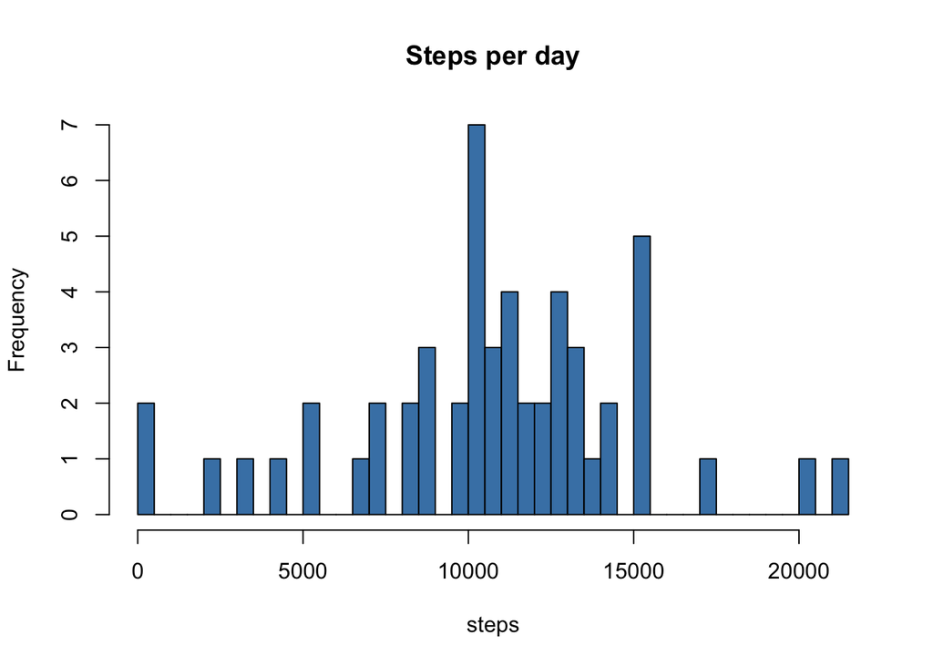

```r
hist_1 <- hist(steps_per_day$steps, main="Steps per day", xlab= "steps",
               col="steelblue", breaks = 50, border="black" )
```

```r
mean_per_day <- mean(steps_per_day$steps)
print(mean_per_day)
```

[1] 10766.19

```r
median_per_day <- median(steps_per_day$steps)
print(median_per_day)
```

[1] 10765